# Imports and CIFAR-10 Data Loading

This cell imports all the necessary libraries for building, training, and visualizing both Keras and PyTorch models. This includes libraries for data handling, visualization, and neural network building.

```python
# Import required libraries for Keras, PyTorch, and visualization
import keras
from keras import datasets, layers, models
from keras.utils import to_categorical
from keras.models import Sequential
from keras.callbacks import EarlyStopping, ReduceLROnPlateau
from tensorflow.keras.models import load_model

import torch
import torch.nn as nn
import torch.optim as optim
import torchvision
import torchvision.transforms as transforms

import matplotlib.pyplot as plt
import numpy as np
from sklearn.model_selection import train_test_split


import seaborn as sns
from tensorflow.keras.models import load_model
from tensorflow.keras.datasets import cifar10
from tensorflow.keras.utils import to_categorical
from sklearn.metrics import classification_report, confusion_matrix
```

# Data Loading and EDA

This cell loads the CIFAR-10 dataset from Keras, sets up class names, and performs Exploratory Data Analysis (EDA) by visualizing the class distribution and displaying a grid of sample images.

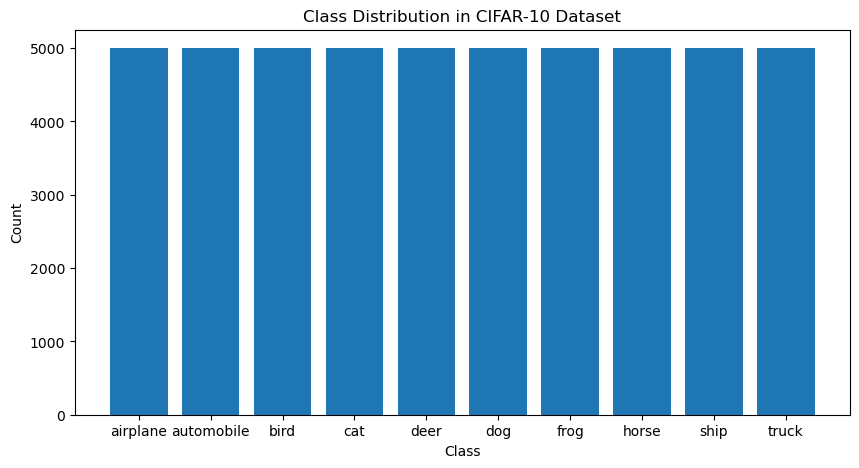

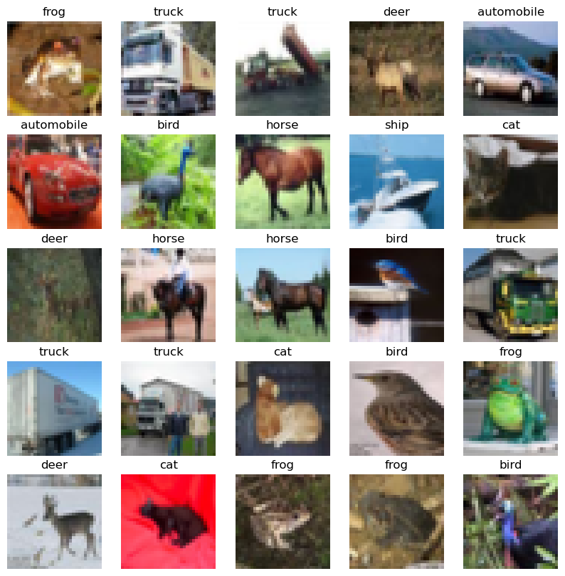

```python
# Load CIFAR-10 dataset and define class names
(train_images, train_labels), (test_images, test_labels) = datasets.cifar10.load_data()
class_names = ['airplane', 'automobile', 'bird', 'cat', 'deer', 'dog', 'frog', 'horse', 'ship', 'truck']

# EDA: Display class distribution in training data
plt.figure(figsize=(10, 5))
unique, counts = np.unique(train_labels, return_counts=True)
plt.bar(class_names, counts)
plt.title("Class Distribution in CIFAR-10 Dataset")
plt.xlabel("Class")
plt.ylabel("Count")
plt.show()

# EDA: Visualize sample images from training data
plt.figure(figsize=(10, 10))
for i in range(25):
    plt.subplot(5, 5, i + 1)
    plt.imshow(train_images[i])
    plt.title(class_names[train_labels[i][0]])
    plt.axis('off')
plt.show()
```

# Data Preprocessing for Keras and PyTorch

This cell prepares the data by normalizing image pixel values, applying one-hot encoding to labels for Keras, and setting up PyTorch DataLoaders with data augmentation for training and testing.

```python
# Split data into train/validation sets and normalize images
train_images, val_images, train_labels, val_labels = train_test_split(train_images, train_labels, test_size=0.2, random_state=7)
train_images, val_images, test_images = train_images / 255.0, val_images / 255.0, test_images / 255.0

# Convert labels to categorical (one-hot encoding)
train_labels = to_categorical(train_labels, 10)
val_labels = to_categorical(val_labels, 10)
test_labels = to_categorical(test_labels, 10)

# PyTorch data transformations and DataLoader setup
transform = transforms.Compose([
    transforms.RandomHorizontalFlip(),
    transforms.RandomCrop(32, padding=4),
    transforms.ToTensor(),
    transforms.Normalize((0.4914, 0.4822, 0.4465), (0.2023, 0.1994, 0.2010))
])

trainset = torchvision.datasets.CIFAR10(root='./data', train=True, download=True, transform=transform)
testset = torchvision.datasets.CIFAR10(root='./data', train=False, download=True, transform=transform)
trainloader = torch.utils.data.DataLoader(trainset, batch_size=64, shuffle=True)
testloader = torch.utils.data.DataLoader(testset, batch_size=64, shuffle=False)
```

```
Files already downloaded and verified
Files already downloaded and verified
```

# Define and Compile Keras Model (Custom CNN)

In this cell, a custom CNN architecture is defined in Keras, with layers for convolution, batch normalization, pooling, dropout, and dense layers.

### Compiling the Model

- Optimizer used during Back Propagation for weight and bias adjustment - Adam (adjusts the learning rate adaptively).
- Loss Function used - Categorical Crossentropy (used when multiple categories/classes are present).
- Metrics used for evaluation - Accuracy

```python
# Define Keras CNN model architecture
keras_model = Sequential([
    layers.Conv2D(32, (3, 3), padding='same', activation='relu', input_shape=(32, 32, 3)),
    layers.BatchNormalization(),
    layers.MaxPooling2D(pool_size=(2, 2)),
    layers.Dropout(0.3),

    layers.Conv2D(64, (3, 3), padding='same', activation='relu'),
    layers.BatchNormalization(),
    layers.MaxPooling2D(pool_size=(2, 2)),
    layers.Dropout(0.4),

    layers.Conv2D(128, (3, 3), padding='same', activation='relu'),
    layers.BatchNormalization(),
    layers.MaxPooling2D(pool_size=(2, 2)),
    layers.Dropout(0.5),

    layers.Flatten(),
    layers.Dense(128, activation='relu'),
    layers.BatchNormalization(),
    layers.Dropout(0.5),
    layers.Dense(10, activation='softmax')
])

# Compile model with optimizer, loss, and metrics
keras_model.compile(optimizer='adam', loss=keras.losses.categorical_crossentropy, metrics=['accuracy'])
keras_model.summary()
```

```
Model: "sequential"
```

```
┏━━━━━━━━━━━━━━━━━━━━━━━━━━━━━━━━━┳━━━━━━━━━━━━━━━━━━━━━━━━┳━━━━━━━━━━━━━━━┓
┃ Layer (type)                    ┃ Output Shape           ┃       Param # ┃
┡━━━━━━━━━━━━━━━━━━━━━━━━━━━━━━━━━╇━━━━━━━━━━━━━━━━━━━━━━━━╇━━━━━━━━━━━━━━━┩
│ conv2d (Conv2D)                 │ (None, 32, 32, 32)     │           896 │
├─────────────────────────────────┼────────────────────────┼───────────────┤
│ batch_normalization             │ (None, 32, 32, 32)     │           128 │
│ (BatchNormalization)            │                        │               │
├─────────────────────────────────┼────────────────────────┼───────────────┤
│ max_pooling2d (MaxPooling2D)    │ (None, 16, 16, 32)     │             0 │
├─────────────────────────────────┼────────────────────────┼───────────────┤
│ dropout (Dropout)               │ (None, 16, 16, 32)     │             0 │
├─────────────────────────────────┼────────────────────────┼───────────────┤
│ conv2d_1 (Conv2D)               │ (None, 16, 16, 64)     │        18,496 │
├─────────────────────────────────┼────────────────────────┼───────────────┤
│ batch_normalization_1           │ (None, 16, 16, 64)     │           256 │
│ (BatchNormalization)            │                        │               │
├─────────────────────────────────┼────────────────────────┼───────────────┤
│ max_pooling2d_1 (MaxPooling2D)  │ (None, 8, 8, 64)       │             0 │
├─────────────────────────────────┼────────────────────────┼───────────────┤
│ dropout_1 (Dropout)             │ (None, 8, 8, 64)       │             0 │
├─────────────────────────────────┼────────────────────────┼───────────────┤
│ conv2d_2 (Conv2D)               │ (None, 8, 8, 128)      │        73,856 │
├─────────────────────────────────┼────────────────────────┼───────────────┤
│ batch_normalization_2           │ (None, 8, 8, 128)      │           512 │
│ (BatchNormalization)            │                        │               │
├─────────────────────────────────┼────────────────────────┼───────────────┤
│ max_pooling2d_2 (MaxPooling2D)  │ (None, 4, 4, 128)      │             0 │
├─────────────────────────────────┼────────────────────────┼───────────────┤
│ dropout_2 (Dropout)             │ (None, 4, 4, 128)      │             0 │
├─────────────────────────────────┼────────────────────────┼───────────────┤
│ flatten (Flatten)               │ (None, 2048)           │             0 │
├─────────────────────────────────┼────────────────────────┼───────────────┤
│ dense (Dense)                   │ (None, 128)            │       262,272 │
├─────────────────────────────────┼────────────────────────┼───────────────┤
│ batch_normalization_3           │ (None, 128)            │           512 │
│ (BatchNormalization)            │                        │               │
├─────────────────────────────────┼────────────────────────┼───────────────┤
│ dropout_3 (Dropout)             │ (None, 128)            │             0 │
├─────────────────────────────────┼────────────────────────┼───────────────┤
│ dense_1 (Dense)                 │ (None, 10)             │         1,290 │
└─────────────────────────────────┴────────────────────────┴───────────────┘
```

```
 Total params: 358,218 (1.37 MB)
```

```
 Trainable params: 357,514 (1.36 MB)
```

```
 Non-trainable params: 704 (2.75 KB)
```

# Train Keras Model with Early Stopping and Learning Rate Reduction

This cell trains the Keras model with early stopping and learning rate reduction. It then saves the trained model to an .h5 file for later use or evaluation.

### Fitting the Model

- Batch Size is used for Adam optimizer.
- Epochs - One epoch is one complete cycle (forward pass + backward pass).

```python
# Train Keras model with early stopping and learning rate reduction
early_stopping = EarlyStopping(monitor='val_loss', patience=10, restore_best_weights=True)
lr_reduction = ReduceLROnPlateau(monitor='val_loss', factor=0.5, patience=5, min_lr=1e-5)

history = keras_model.fit(train_images, train_labels, batch_size=64, epochs=50,
                          validation_data=(val_images, val_labels),
                          callbacks=[early_stopping, lr_reduction])

# Save trained model
keras_model.save("keras_custom_cnn_model.h5")
```

```
625/625 ━━━━━━━━━━━━━━━━━━━━ 21s 33ms/step - accuracy: 0.3069 - loss: 2.1960 - val_accuracy: 0.3005 - val_loss: 2.0322 - learning_rate: 0.0010
625/625 ━━━━━━━━━━━━━━━━━━━━ 21s 33ms/step - accuracy: 0.4870 - loss: 1.4144 - val_accuracy: 0.3884 - val_loss: 1.7966 - learning_rate: 0.0010
625/625 ━━━━━━━━━━━━━━━━━━━━ 21s 34ms/step - accuracy: 0.5477 - loss: 1.2624 - val_accuracy: 0.5673 - val_loss: 1.2247 - learning_rate: 0.0010
625/625 ━━━━━━━━━━━━━━━━━━━━ 22s 34ms/step - accuracy: 0.5900 - loss: 1.1624 - val_accuracy: 0.6210 - val_loss: 1.1026 - learning_rate: 0.0010
625/625 ━━━━━━━━━━━━━━━━━━━━ 22s 36ms/step - accuracy: 0.6196 - loss: 1.0861 - val_accuracy: 0.6610 - val_loss: 0.9499 - learning_rate: 0.0010
625/625 ━━━━━━━━━━━━━━━━━━━━ 22s 35ms/step - accuracy: 0.6387 - loss: 1.0287 - val_accuracy: 0.5661 - val_loss: 1.2685 - learning_rate: 0.0010
625/625 ━━━━━━━━━━━━━━━━━━━━ 22s 36ms/step - accuracy: 0.6457 - loss: 0.9954 - val_accuracy: 0.6320 - val_loss: 1.0550 - learning_rate: 0.0010
625/625 ━━━━━━━━━━━━━━━━━━━━ 23s 37ms/step - accuracy: 0.6708 - loss: 0.9451 - val_accuracy: 0.6723 - val_loss: 0.9178 - learning_rate: 0.0010
625/625 ━━━━━━━━━━━━━━━━━━━━ 24s 38ms/step - accuracy: 0.6752 - loss: 0.9264 - val_accuracy: 0.6825 - val_loss: 0.9253 - learning_rate: 0.0010
625/625 ━━━━━━━━━━━━━━━━━━━━ 27s 43ms/step - accuracy: 0.6762 - loss: 0.9253 - val_accuracy: 0.7014 - val_loss: 0.8472 - learning_rate: 0.0010
625/625 ━━━━━━━━━━━━━━━━━━━━ 23s 37ms/step - accuracy: 0.6924 - loss: 0.8858 - val_accuracy: 0.6962 - val_loss: 0.8602 - learning_rate: 0.0010
625/625 ━━━━━━━━━━━━━━━━━━━━ 23s 37ms/step - accuracy: 0.6991 - loss: 0.8745 - val_accuracy: 0.7049 - val_loss: 0.8411 - learning_rate: 0.0010
625/625 ━━━━━━━━━━━━━━━━━━━━ 27s 43ms/step - accuracy: 0.7006 - loss: 0.8496 - val_accuracy: 0.6920 - val_loss: 0.8981 - learning_rate: 0.0010
625/625 ━━━━━━━━━━━━━━━━━━━━ 27s 43ms/step - accuracy: 0.7068 - loss: 0.8378 - val_accuracy: 0.7346 - val_loss: 0.7671 - learning_rate: 0.0010
625/625 ━━━━━━━━━━━━━━━━━━━━ 27s 44ms/step - accuracy: 0.7121 - loss: 0.8270 - val_accuracy: 0.6652 - val_loss: 0.9751 - learning_rate: 0.0010
625/625 ━━━━━━━━━━━━━━━━━━━━ 28s 44ms/step - accuracy: 0.7192 - loss: 0.8112 - val_accuracy: 0.6301 - val_loss: 1.1115 - learning_rate: 0.0010
625/625 ━━━━━━━━━━━━━━━━━━━━ 26s 42ms/step - accuracy: 0.7165 - loss: 0.8113 - val_accuracy: 0.6736 - val_loss: 0.9573 - learning_rate: 0.0010
625/625 ━━━━━━━━━━━━━━━━━━━━ 26s 42ms/step - accuracy: 0.7230 - loss: 0.7925 - val_accuracy: 0.6382 - val_loss: 1.0933 - learning_rate: 0.0010
625/625 ━━━━━━━━━━━━━━━━━━━━ 27s 43ms/step - accuracy: 0.7264 - loss: 0.7808 - val_accuracy: 0.7511 - val_loss: 0.7153 - learning_rate: 0.0010
625/625 ━━━━━━━━━━━━━━━━━━━━ 27s 43ms/step - accuracy: 0.7246 - loss: 0.7888 - val_accuracy: 0.7274 - val_loss: 0.7868 - learning_rate: 0.0010
625/625 ━━━━━━━━━━━━━━━━━━━━ 28s 45ms/step - accuracy: 0.7374 - loss: 0.7548 - val_accuracy: 0.6805 - val_loss: 0.9008 - learning_rate: 0.0010
625/625 ━━━━━━━━━━━━━━━━━━━━ 28s 44ms/step - accuracy: 0.7354 - loss: 0.7617 - val_accuracy: 0.7267 - val_loss: 0.7849 - learning_rate: 0.0010
625/625 ━━━━━━━━━━━━━━━━━━━━ 28s 45ms/step - accuracy: 0.7431 - loss: 0.7509 - val_accuracy: 0.7525 - val_loss: 0.7113 - learning_rate: 0.0010
625/625 ━━━━━━━━━━━━━━━━━━━━ 27s 44ms/step - accuracy: 0.7359 - loss: 0.7540 - val_accuracy: 0.7579 - val_loss: 0.7079 - learning_rate: 0.0010
625/625 ━━━━━━━━━━━━━━━━━━━━ 27s 43ms/step - accuracy: 0.7427 - loss: 0.7365 - val_accuracy: 0.7671 - val_loss: 0.6706 - learning_rate: 0.0010
625/625 ━━━━━━━━━━━━━━━━━━━━ 26s 42ms/step - accuracy: 0.7446 - loss: 0.7283 - val_accuracy: 0.7671 - val_loss: 0.6743 - learning_rate: 0.0010
625/625 ━━━━━━━━━━━━━━━━━━━━ 27s 42ms/step - accuracy: 0.7438 - loss: 0.7344 - val_accuracy: 0.7142 - val_loss: 0.8428 - learning_rate: 0.0010
625/625 ━━━━━━━━━━━━━━━━━━━━ 27s 43ms/step - accuracy: 0.7470 - loss: 0.7229 - val_accuracy: 0.7233 - val_loss: 0.8148 - learning_rate: 0.0010
625/625 ━━━━━━━━━━━━━━━━━━━━ 26s 42ms/step - accuracy: 0.7426 - loss: 0.7313 - val_accuracy: 0.7648 - val_loss: 0.6789 - learning_rate: 0.0010
625/625 ━━━━━━━━━━━━━━━━━━━━ 27s 42ms/step - accuracy: 0.7491 - loss: 0.7072 - val_accuracy: 0.7759 - val_loss: 0.6471 - learning_rate: 0.0010
625/625 ━━━━━━━━━━━━━━━━━━━━ 28s 44ms/step - accuracy: 0.7518 - loss: 0.7075 - val_accuracy: 0.7388 - val_loss: 0.7695 - learning_rate: 0.0010
625/625 ━━━━━━━━━━━━━━━━━━━━ 27s 43ms/step - accuracy: 0.7540 - loss: 0.7068 - val_accuracy: 0.7591 - val_loss: 0.7108 - learning_rate: 0.0010
625/625 ━━━━━━━━━━━━━━━━━━━━ 27s 43ms/step - accuracy: 0.7545 - loss: 0.7018 - val_accuracy: 0.7717 - val_loss: 0.6530 - learning_rate: 0.0010
```

[output cut: 17 more lines]

```
WARNING:absl:You are saving your model as an HDF5 file via `model.save()` or `keras.saving.save_model(model)`. This file format is considered legacy. We recommend using instead the native Keras format, e.g. `model.save('my_model.keras')` or `keras.saving.save_model(model, 'my_model.keras')`.
```

# Plot Keras Model Loss and Accuracy Curves

This cell visualizes the training and validation loss and accuracy curves for the Keras model, aiding in model performance analysis.

### Visualizing the Evaluation

- Loss Curve - Comparing the Training Loss with the Testing Loss over increasing Epochs.
- Accuracy Curve - Comparing the Training Accuracy with the Testing Accuracy over increasing Epochs.

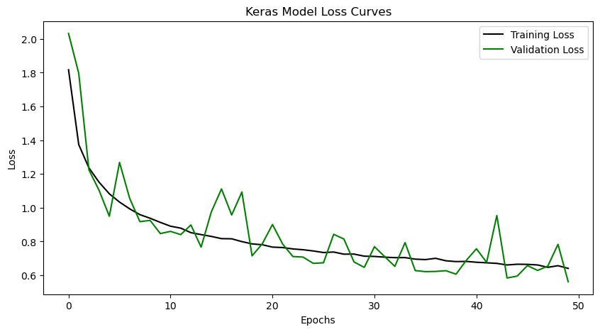

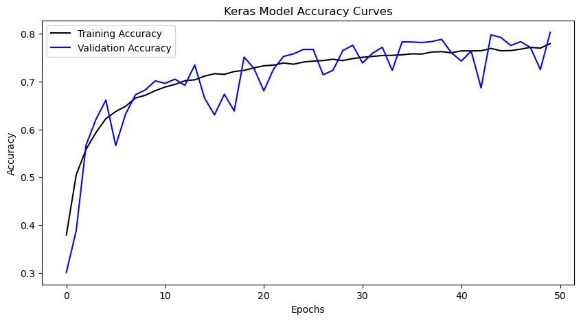

```python
# Plot training/validation loss and accuracy curves for Keras model
plt.figure(figsize=(10, 5))

plt.plot(history.history['loss'], 'black', label='Training Loss')
plt.plot(history.history['val_loss'], 'green', label='Validation Loss')
plt.xlabel('Epochs')
plt.ylabel('Loss')
plt.legend()
plt.title('Keras Model Loss Curves')

plt.figure(figsize=(10, 5))
plt.plot(history.history['accuracy'], 'black', label='Training Accuracy')
plt.plot(history.history['val_accuracy'],'blue', label='Validation Accuracy')
plt.xlabel('Epochs')
plt.ylabel('Accuracy')
plt.legend()
plt.title('Keras Model Accuracy Curves')

plt.show()
```

# Evaluating and predicting Keras Model on Test Set

This cell evaluates the trained Keras model on the test set, printing the test accuracy.

```python
# Load the CIFAR-10 dataset
(_, _), (X_test, y_test) = cifar10.load_data()

# Preprocess the test data as done during training
X_test = X_test.astype('float32') / 255.0  # Normalize pixel values to [0, 1] range
y_test = to_categorical(y_test, 10)  # One-hot encode the labels

# Load the trained Keras model from the .h5 file
model_keras = load_model('keras_custom_cnn_model.h5')
```

```
WARNING:absl:Compiled the loaded model, but the compiled metrics have yet to be built. `model.compile_metrics` will be empty until you train or evaluate the model.
```

```python
# Evaluate the model on the test data
test_loss, test_accuracy = model_keras.evaluate(X_test, y_test, verbose=2)
print(f"Test Loss: {test_loss:.4f}")
print(f"Test Accuracy: {test_accuracy:.4f}")

# Generate predictions on the test set
y_pred_prob = model_keras.predict(X_test)
y_pred = np.argmax(y_pred_prob, axis=1)
y_true = np.argmax(y_test, axis=1)
```

```
313/313 - 2s - 5ms/step - accuracy: 0.8075 - loss: 0.5484
Test Loss: 0.5484
Test Accuracy: 0.8075
313/313 ━━━━━━━━━━━━━━━━━━━━ 2s 5ms/step
```

```
Classification Report:
               precision    recall  f1-score   support

           0       0.81      0.84      0.82      1000
           1       0.91      0.92      0.91      1000
           2       0.76      0.70      0.73      1000
           3       0.68      0.58      0.63      1000
           4       0.76      0.79      0.77      1000
           5       0.72      0.71      0.72      1000
           6       0.85      0.88      0.86      1000
           7       0.83      0.85      0.84      1000
           8       0.85      0.92      0.89      1000
           9       0.88      0.88      0.88      1000

    accuracy                           0.81     10000
   macro avg       0.80      0.81      0.81     10000
weighted avg       0.80      0.81      0.81     10000
```

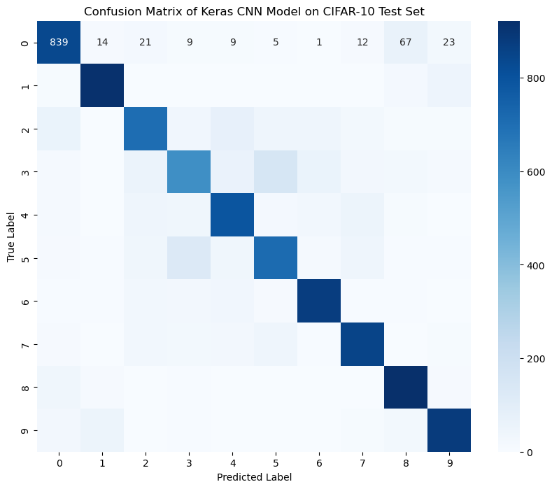

```python
# Print classification report
print("Classification Report:\n", classification_report(y_true, y_pred))

# Plot confusion matrix
conf_matrix = confusion_matrix(y_true, y_pred)
plt.figure(figsize=(10, 8))
sns.heatmap(conf_matrix, annot=True, fmt='d', cmap='Blues', xticklabels=range(10), yticklabels=range(10))
plt.xlabel("Predicted Label")
plt.ylabel("True Label")
plt.title("Confusion Matrix of Keras CNN Model on CIFAR-10 Test Set")
plt.show()
```

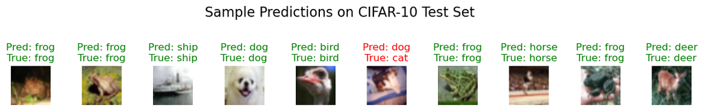

```python
# Define CIFAR-10 class names
class_names = ['airplane', 'automobile', 'bird', 'cat', 'deer',
               'dog', 'frog', 'horse', 'ship', 'truck']

# Visualize some sample predictions
num_samples = 10
indices = np.random.choice(len(X_test), num_samples, replace=False)

plt.figure(figsize=(15, 10))
for i, idx in enumerate(indices):
    ax = plt.subplot(10, num_samples, i + 1)
    plt.imshow(X_test[idx])
    pred_label = class_names[y_pred[idx]]
    true_label = class_names[y_true[idx]]
    color = 'green' if pred_label == true_label else 'red'
    plt.title(f"Pred: {pred_label}\nTrue: {true_label}", color=color)
    plt.axis("off")
plt.suptitle("Sample Predictions on CIFAR-10 Test Set", fontsize=16)
plt.show()
```

# Define, Train, and Save PyTorch Model (ResNet-18)

This cell defines and trains the ResNet-18 model in PyTorch. After training, the model’s state dictionary is saved to a .pth file for future usage or testing.

```python
# Load ResNet-18 and modify for CIFAR-10
model = torchvision.models.resnet18(pretrained=False, num_classes=10)
device = torch.device("cuda" if torch.cuda.is_available() else "cpu")
model = model.to(device)
criterion = nn.CrossEntropyLoss()
optimizer = optim.Adam(model.parameters(), lr=0.001)

# Define PyTorch training function with tracking of training and validation loss and accuracy
def train_model(model, trainloader, testloader, epochs=20):
    training_loss, validation_loss = [], []
    training_accuracy, validation_accuracy = [], []

    for epoch in range(epochs):
        model.train()
        running_loss, correct, total = 0.0, 0, 0

        for inputs, labels in trainloader:
            inputs, labels = inputs.to(device), labels.to(device)
            optimizer.zero_grad()
            outputs = model(inputs)
            loss = criterion(outputs, labels)
            loss.backward()
            optimizer.step()

            # Update running loss and correct predictions count for training
            running_loss += loss.item()
            _, predicted = torch.max(outputs.data, 1)
            total += labels.size(0)
            correct += (predicted == labels).sum().item()

        # Calculate average training loss and accuracy for the epoch
        epoch_training_loss = running_loss / len(trainloader)
        epoch_training_accuracy = 100 * correct / total
        training_loss.append(epoch_training_loss)
        training_accuracy.append(epoch_training_accuracy)

        # Validation phase
        model.eval()
        val_running_loss, correct, total = 0.0, 0, 0
        with torch.no_grad():
            for inputs, labels in testloader:
                inputs, labels = inputs.to(device), labels.to(device)
                outputs = model(inputs)
                loss = criterion(outputs, labels)
                val_running_loss += loss.item()

                # Update correct predictions count for validation
                _, predicted = torch.max(outputs.data, 1)
                total += labels.size(0)
                correct += (predicted == labels).sum().item()

        # Calculate average validation loss and accuracy for the epoch
        epoch_validation_loss = val_running_loss / len(testloader)
        epoch_validation_accuracy = 100 * correct / total
        validation_loss.append(epoch_validation_loss)
        validation_accuracy.append(epoch_validation_accuracy)

        print(f"Epoch [{epoch + 1}/{epochs}], Training Loss: {epoch_training_loss:.4f}, "
              f"Training Accuracy: {epoch_training_accuracy:.2f}%, "
              f"Validation Loss: {epoch_validation_loss:.4f}, "
              f"Validation Accuracy: {epoch_validation_accuracy:.2f}%")

    return training_loss, training_accuracy, validation_loss, validation_accuracy

# Train PyTorch model and save it
train_loss, train_acc, val_loss, val_acc = train_model(model, trainloader, testloader, epochs=20)
torch.save(model.state_dict(), "pytorch_resnet18_cifar10.pth")
```

```
Epoch [1/20], Training Loss: 1.5490, Training Accuracy: 43.67%, Validation Loss: 1.6377, Validation Accuracy: 44.39%
Epoch [2/20], Training Loss: 1.1908, Training Accuracy: 57.65%, Validation Loss: 1.1173, Validation Accuracy: 60.25%
Epoch [3/20], Training Loss: 1.0196, Training Accuracy: 64.04%, Validation Loss: 0.9578, Validation Accuracy: 66.41%
Epoch [4/20], Training Loss: 0.9236, Training Accuracy: 67.77%, Validation Loss: 0.9036, Validation Accuracy: 68.70%
Epoch [5/20], Training Loss: 0.8448, Training Accuracy: 70.56%, Validation Loss: 0.8319, Validation Accuracy: 71.49%
Epoch [6/20], Training Loss: 0.7882, Training Accuracy: 72.61%, Validation Loss: 0.7688, Validation Accuracy: 73.72%
Epoch [7/20], Training Loss: 0.7384, Training Accuracy: 74.36%, Validation Loss: 0.8201, Validation Accuracy: 71.90%
Epoch [8/20], Training Loss: 0.7078, Training Accuracy: 75.49%, Validation Loss: 0.7180, Validation Accuracy: 74.97%
Epoch [9/20], Training Loss: 0.6727, Training Accuracy: 76.76%, Validation Loss: 0.6834, Validation Accuracy: 76.00%
Epoch [10/20], Training Loss: 0.6337, Training Accuracy: 77.99%, Validation Loss: 0.6866, Validation Accuracy: 76.55%
Epoch [11/20], Training Loss: 0.6158, Training Accuracy: 78.45%, Validation Loss: 0.6850, Validation Accuracy: 76.79%
Epoch [12/20], Training Loss: 0.5918, Training Accuracy: 79.66%, Validation Loss: 0.6171, Validation Accuracy: 79.06%
Epoch [13/20], Training Loss: 0.5614, Training Accuracy: 80.50%, Validation Loss: 0.6404, Validation Accuracy: 78.04%
Epoch [14/20], Training Loss: 0.5429, Training Accuracy: 81.22%, Validation Loss: 0.6168, Validation Accuracy: 78.61%
Epoch [15/20], Training Loss: 0.5357, Training Accuracy: 81.56%, Validation Loss: 0.6611, Validation Accuracy: 77.14%
Epoch [16/20], Training Loss: 0.5109, Training Accuracy: 82.17%, Validation Loss: 0.6131, Validation Accuracy: 79.33%
Epoch [17/20], Training Loss: 0.4919, Training Accuracy: 82.81%, Validation Loss: 0.6172, Validation Accuracy: 79.41%
Epoch [18/20], Training Loss: 0.4772, Training Accuracy: 83.37%, Validation Loss: 0.5991, Validation Accuracy: 79.49%
Epoch [19/20], Training Loss: 0.4638, Training Accuracy: 83.96%, Validation Loss: 0.5695, Validation Accuracy: 80.70%
Epoch [20/20], Training Loss: 0.4485, Training Accuracy: 84.44%, Validation Loss: 0.6032, Validation Accuracy: 79.83%
```

# Plot PyTorch Model Loss and Accuracy Curves

This cell visualizes the training and validation loss and accuracy curves for the PyTorch model, aiding in model performance analysis.

### Visualizing the Evaluation

- Loss Curve - Comparing the Training Loss with the Testing Loss over increasing Epochs.
- Accuracy Curve - Comparing the Training Accuracy with the Testing Accuracy over increasing Epochs.

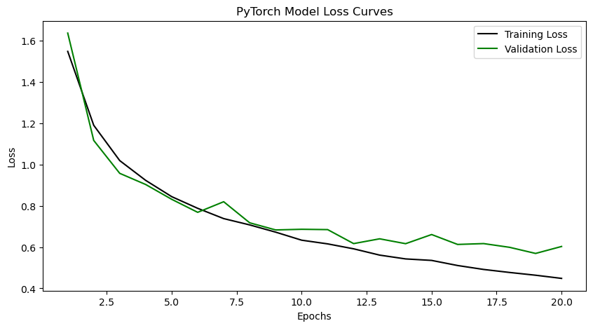

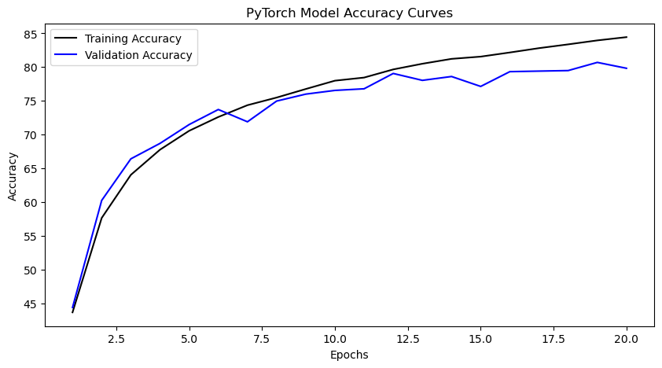

```python
# Plot Loss Curves
plt.figure(figsize=(10, 5))
plt.plot(range(1, 20 + 1), train_loss,'black', label='Training Loss')
plt.plot(range(1, 20 + 1), val_loss,'green', label='Validation Loss')
plt.xlabel('Epochs')
plt.ylabel('Loss')
plt.title('PyTorch Model Loss Curves')
plt.legend()
plt.show()

# Plot Accuracy Curves
plt.figure(figsize=(10, 5))
plt.plot(range(1, 20 + 1), train_acc,'black', label='Training Accuracy')
plt.plot(range(1, 20 + 1), val_acc,'blue', label='Validation Accuracy')
plt.xlabel('Epochs')
plt.ylabel('Accuracy')
plt.title('PyTorch Model Accuracy Curves')
plt.legend()
plt.show()
```

# Evaluating PyTorch Model on Test Set

This cell evaluates the trained PyTorch model on the test set, printing the test accuracy.

```python
# Define evaluation function for PyTorch model
def evaluate_model(model, testloader):
    model.eval()
    correct, total = 0, 0
    with torch.no_grad():
        for inputs, labels in testloader:
            inputs, labels = inputs.to(device), labels.to(device)
            outputs = model(inputs)
            _, predicted = torch.max(outputs.data, 1)
            total += labels.size(0)
            correct += (predicted == labels).sum().item()
    accuracy = 100 * correct / total
    print(f'PyTorch Model - Test Accuracy: {accuracy:.2f}%')

# Evaluate and print accuracy
evaluate_model(model, testloader)
```

```
PyTorch Model - Test Accuracy: 80.03%
```